# Determining alpha values for ConScape

### General distance transformation equation

Visualize distance transformation equation

x -> exp(-x * alpha)

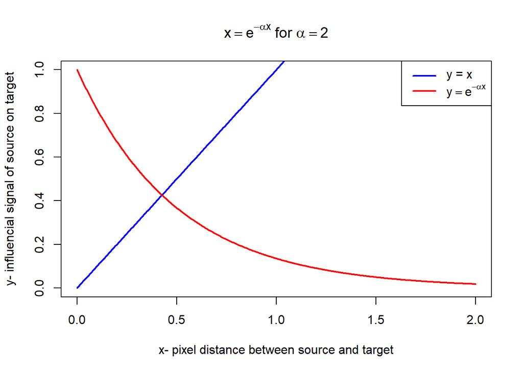

```r
# Choose an alpha value
alpha <- 2

# Create a sequence of x values
x_vals <- seq(0, 2, length.out = 500)

# Left-hand side: y = x
lhs <- x_vals

# Right-hand side: y = exp(-alpha * x)
rhs <- exp(-alpha * x_vals)

# Plot both functions
plot(x_vals, lhs, type = "l", col = "blue", lwd = 2, ylim = c(0, 1),
     ylab = "y- influencial signal of source on target", xlab = "x- pixel distance between source and target", main = bquote(x == e^{-alpha * x} ~ "for" ~ alpha == .(alpha)))
lines(x_vals, rhs, col = "red", lwd = 2)

# Add a legend
legend("topright", legend = c("y = x", bquote(y == e^{-alpha * x})),
       col = c("blue", "red"), lwd = 2)
```

### Finding alpha for badger

For badger, the literature says that they have an average dispersal of 11 km in western Canada. Let’s assume our map resolution is 1000 m.

We’ll assume that badger dispersal has a normal distribution. Make a normal distribution with 11 as the mean.

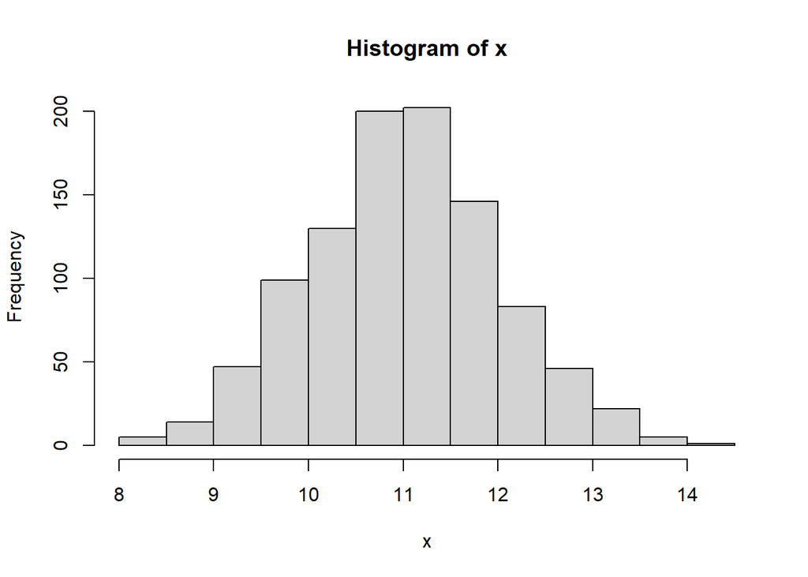

```r
set.seed(123)  # for reproducibility
x <- rnorm(1000, mean = 11, sd = 1)
hist(x)
```

Find the cutoff where only 5% lies to the right (greater than alternative)

```r
qnorm(0.95, mean = 11, sd = 1)
```

```
## [1] 12.64485
```

Approximately, 95% of badgers disperse 12.64 km or less

I think we can use this distance to solve for the alpha value, if we assume that 95% of the signal is lost between source and target pixels at 12.64 km (also 12.64 pixels in our case)

exp(−alpha*12.64)=0.05 −alpha* 12.64= ln(0.05) alpha = - (ln(0.05)/12.64))

```r
alpha_badger <- -log(0.05) / 12.64
paste0("Alpha value to use for badger is ", round(alpha_badger, 3))
```

```
## [1] "Alpha value to use for badger is 0.237"
```

Plot it

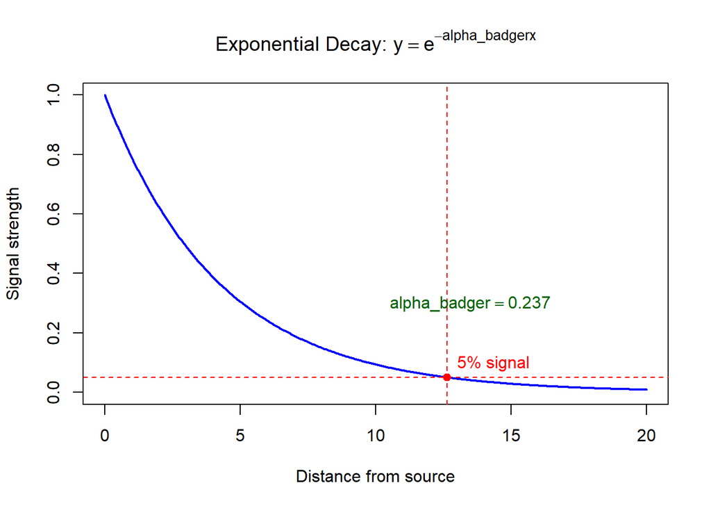

```r
# Parameters
x_vals <- seq(0, 20, length.out = 500)
y_vals <- exp(-alpha_badger * x_vals)

# Plot
plot(x_vals, y_vals, type = "l", col = "blue", lwd = 2,
     main = expression(paste("Exponential Decay: ", y == e^{-alpha_badger * x})),
     xlab = "Distance from source", ylab = "Signal strength", ylim = c(0, 1))

# Highlight the 95% loss point
abline(v = 12.64, col = "red", lty = 2)
abline(h = 0.05, col = "red", lty = 2)
points(12.64, 0.05, pch = 19, col = "red")
text(12.64, 0.1, labels = "5% signal", pos = 4, col = "red")
text(13.5, 0.3, labels = bquote(alpha_badger == .(round(alpha_badger, 3))), col = "darkgreen")
```

### Finding alpha for mule deer

Do the same thing for the other species

We want to model mule deer as having an average dispersal of 15 km. Again we’ll assume a 1000 m map resolution

```r
paste0("Approx. 95% of mule deer disperse ", round(qnorm(0.95, mean = 15, sd = 1), 3), " km or less")
```

```
## [1] "Approx. 95% of mule deer disperse 16.645 km or less"
```

```r
alpha_muledeer <- -log(0.05) / 16.645
paste0("Alpha value to use for mule deer is ", round(alpha_muledeer, 3))
```

```
## [1] "Alpha value to use for mule deer is 0.18"
```

Plot it

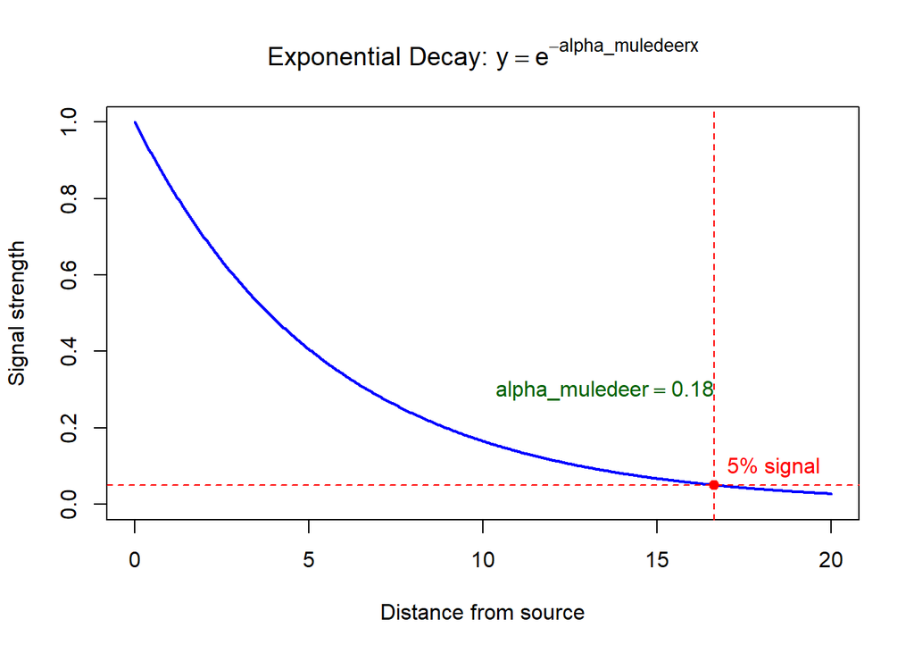

```r
# Parameters
x_vals <- seq(0, 20, length.out = 500)
y_vals <- exp(-alpha_muledeer * x_vals)

# Plot
plot(x_vals, y_vals, type = "l", col = "blue", lwd = 2,
     main = expression(paste("Exponential Decay: ", y == e^{-alpha_muledeer * x})),
     xlab = "Distance from source", ylab = "Signal strength", ylim = c(0, 1))

# Highlight the 95% loss point
abline(v = 16.645, col = "red", lty = 2)
abline(h = 0.05, col = "red", lty = 2)
points(16.645, 0.05, pch = 19, col = "red")
text(16.645, 0.1, labels = "5% signal", pos = 4, col = "red")
text(13.5, 0.3, labels = bquote(alpha_muledeer == .(round(alpha_muledeer, 3))), col = "darkgreen")
```

### Extra alphas to model

I also want to models representing average dispersals of 1 and 5 kms

```r
alpha_mean1km <- -log(0.05)/qnorm(0.95, mean = 1, sd = 1)
alpha_mean1km
```

```
## [1] 1.132665
```

```r
alpha_mean5km <- -log(0.05)/qnorm(0.95, mean = 5, sd = 1)
alpha_mean5km
```

```
## [1] 0.450835
```